# Assemble grouping traits and gapfill using MICE

#### 3.2.2.5 porifera

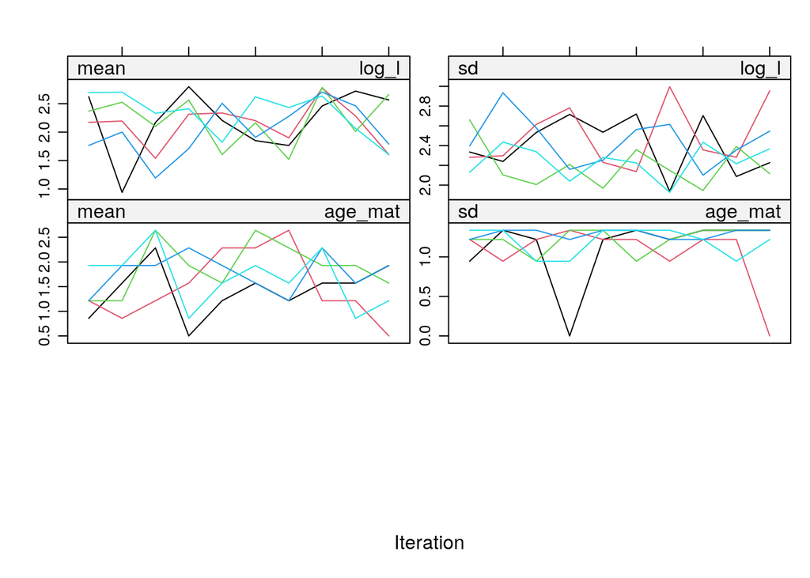

```r
traits_complete <- read_csv(post_impute_f) %>%
  mutate(wcol = factor(wcol, levels = wcol_levels),
         adult_mob = factor(adult_mob, levels = mob_levels, ordered = TRUE))

ggplot(traits_complete, aes(x = wcol)) +
  geom_histogram(stat = 'count') +
  labs(title = 'water col pos post-imputation')
ggplot(traits_premice %>% filter(!is.na(wcol)), aes(x = wcol)) +
  geom_histogram(stat = 'count') +
  labs(title = 'water col pos pre-imputation')

ggplot(traits_complete, aes(x = adult_mob)) +
  geom_histogram(stat = 'count') +
  labs(title = 'adult mobility post-imputation')
ggplot(traits_premice %>% filter(!is.na(adult_mob)), aes(x = adult_mob)) +
  geom_histogram(stat = 'count') +
  labs(title = 'adult mobility pre-imputation')
```

## 3.3 Ensemble averaging

Take mean for each species across all imputation models. For categorical variables, examine the mode. Note in many cases, multiple observations of a variable for a particular species resulted in multiple imputations (e.g., *Gadus morhua*) - these are averaged across all observations.

```r
traits_complete <- read_csv(post_impute_f) %>%
  mutate(wcol = factor(wcol, levels = wcol_levels),
         adult_mob = factor(adult_mob, levels = mob_levels, ordered = TRUE))

traits_cat_ensemble <- traits_complete %>%
  group_by(species, adult_mob) %>%
  mutate(n_mob = n()) %>%
  group_by(species, wcol) %>%
  mutate(n_wcol = n()) %>%
  group_by(species) %>%
  summarize(n_vals = n(),
            mob_mean = mean(as.numeric(adult_mob)),
            wcol_mean = mean(as.numeric(wcol)),
            mob_sd = sd(as.numeric(adult_mob)),
            wcol_sd = sd(as.numeric(wcol)),
            mode_mob = first(adult_mob[n_mob == max(n_mob)]),
            pct_mob = max(n_mob) / n_vals,
            mode_wcol = first(wcol[n_wcol == max(n_wcol)]),
            pct_wcol = max(n_wcol) / n_vals)

traits_num_ensemble <- traits_complete %>%
  group_by(species) %>%
  summarize(across(c(log_l, log_f, age_mat, troph), .fns = list(mean = mean, sd = sd)),
            n_vals = n())

traits_ensemble <- traits_cat_ensemble %>%
  select(species, mode_mob, mode_wcol, mob_mean, mob_sd, wcol_mean, wcol_sd) %>%
  full_join(traits_num_ensemble, by = 'species')
```

## 3.4 Performing MICE to fill gaps - chunked by class

With an improved dataset, we can use MICE to impute missing values.

- MICE on datasets only from FishBase, vs MICE on datasets enhanced with values from Vuln trait bins
- Continuous variables: log(length), log(fecundity), age to maturity, trophic level
- Categorical variables: water column position; also order, family (based on Boyce et al. 2021)

Here, chunk out the dataset by order, or if fewer than 30 obs, by class then phylum. Keeping categorical variables for taxonomic ranks can perhaps affect outcomes as a fixed effect, but what if the relationship among variables is fundamentally different between, say, echinoderms and mammals?

This may also have the effect of speeding processing time since smaller subsets are being analyzed, which may be helpful for eventual cross validation testing.

For classes where few observations exist, aggregate up to phylum level?

### 3.4.1 set up dataset for imputation

```r
wcol_levels <- c('rf', 'pel', 'ben', 'bp')
mob_levels  <- c('ses', 'sed', 'mob', 'mig')

traits_premice_cls <- traits2_all %>%
  mutate(log_l = log(length), log_f = log(fecund)) %>%
  select(species, phylum, class, order, family,
         log_l, log_f, troph, age_mat, wcol, adult_mob) %>%
  filter(rowSums(is.na(.)) <= 4) %>%
    ### dropping 6-NA rows, we're left with 103k obs of 80730 spp...
    ### but 40k of those obs are water col position only...
    ### dropping 5- and 6-NA rows, we're left with 61k obs of 38900 spp...
  mutate(wcol      = factor(wcol, levels = wcol_levels, ordered = FALSE),
         adult_mob = str_extract(adult_mob, '^...'),
         adult_mob = factor(adult_mob, levels = mob_levels, ordered = TRUE)) %>%
  mutate(phylum = factor(phylum, ordered = FALSE),
         class  = factor(class, ordered = FALSE),
         order  = factor(order, ordered = FALSE),
         family = factor(family, ordered = FALSE))

am_spp <- get_am_spp_info()
# n_samples <- 1000
# set.seed(42)
### taxonomic ranks to keep
keep_ranks <- c('order', 'family')

traits_premice <- traits_premice_cls %>%
  # filter(species %in% am_spp$sciname) %>%
  # sample_n(n_samples) %>%
  select(species, phylum, class, all_of(keep_ranks),
         log_l, log_f, troph, age_mat, wcol, adult_mob)

traits_premice_chunk_order <- traits_premice %>%
  group_by(order) %>%
  filter(n_distinct(species) >= 30) %>%
  mutate(chunk = 'order',
         chunk_name = order,
         n_chunk = n_distinct(species)) %>%
  ungroup()
traits_premice_chunk_class <- traits_premice %>%
  group_by(class) %>%
  filter(!species %in% traits_premice_chunk_order$species) %>%
  filter(n_distinct(species) >= 30) %>%
  mutate(chunk = 'class',
         chunk_name = class,
         n_chunk = n_distinct(species)) %>%
  ungroup()
traits_premice_chunk_phylum <- traits_premice %>%
  group_by(phylum) %>%
  filter(!species %in% traits_premice_chunk_order$species) %>%
  filter(!species %in% traits_premice_chunk_class$species) %>%
  mutate(chunk = 'phylum',
         chunk_name = phylum,
         n_chunk = n_distinct(species)) %>%
  ungroup()

traits_premice_chunk <- bind_rows(traits_premice_chunk_order,
                                  traits_premice_chunk_class,
                                  traits_premice_chunk_phylum)

n_chunks <- n_distinct(traits_premice_chunk$chunk_name)
### 177 different chunks of highly variable size
```

### 3.4.2 Set up predictor matrix and method vector

Create a blank run (no iterations) to generate a prediction matrix and a methods vector, then update these for imputation by order, class, and phylum chunks…

- Order chunks: impute by variables and family
- Class chunks: impute by variables and family, order
- Phylum chunks: impute by variables and family, order, class

```r
traits_blank <- traits_premice_chunk %>%
  select(-contains('chunk'), -phylum)
blank_run <- mice(traits_blank, maxit = 0)

### set up predictor matrix
pred_mtx_phy <- blank_run$pred

pred_mtx_phy[ , 'species'] <- 0
  ### species column is all zeros - ignored for imputation

pred_mtx_phy[c('species'), ] <- 0
pred_mtx_phy[c('class', 'order', 'family'), ] <- 0
  ### don't impute values for these... (should not be an issue since no NAs)
pred_mtx_cls <- pred_mtx_phy[-which(rownames(pred_mtx_phy) == 'class'), ]
pred_mtx_cls <- pred_mtx_cls[, -which(colnames(pred_mtx_cls) == 'class')]

pred_mtx_ord <- pred_mtx_cls[-which(rownames(pred_mtx_cls) == 'order'), ]
pred_mtx_ord <- pred_mtx_ord[, -which(colnames(pred_mtx_ord) == 'order')]

meth_vec_phy <- blank_run$meth
meth_vec_phy[c('class', 'order', 'family')] <- 'polyreg'
#   ### set method for non-ordered categoricals
meth_vec_cls <- meth_vec_phy[-which(names(meth_vec_phy) == 'class')]
meth_vec_ord <- meth_vec_cls[-which(names(meth_vec_cls) == 'order')]
```

### 3.4.3 perform the imputation!

```r
### write out traits pre-imputation for reference
write_csv(traits_premice,  here_anx('mice/gp_traits_mice_preimputation.csv'))

### set up file for imputed traits
post_impute_f <- here_anx('mice/gp_traits_mice.csv')

### .Rdata path for saving the imputation `mids` object
impute_object_f <- here_anx('mice/gp_traits_mice_results.RData')

if(!file.exists(post_impute_f)) {
  ### unlink(post_impute_f)
  system.time({
    imp <- mice(traits_premice,
                m = 5, maxit = 10,
                method = meth_vec,
                predictorMatrix = pred_mtx,
                seed = 42)
  })

  ### complete the trait set and write out the traits post-imputation. For
  ### file size, convert wcol and adult_mob to integers instead of character
  traits_complete <- complete(imp, 'long') %>%
    select(-all_of(keep_ranks)) %>% ### can reattach higher ranks easily
    mutate(log_l = round(log_l, 5),
           log_f = round(log_f, 5),
           age_mat = round(age_mat, 5))
  ### from above:
  ### wcol_levels <- c('rf',  'pel', 'ben', 'bp')
  ### mob_levels  <- c('ses', 'sed', 'mob', 'mig')

  write_csv(traits_complete, post_impute_f)
  ### write out results to .RData
  save(imp, file = impute_object_f)
}
```

```r
load(impute_object_f) ### stored as 'imp'
summary(imp)

plot(imp) ### do troph, log_f, and age_mat have convergence issues?

densityplot(imp) ### doesn't show categoricals?
```

```r
traits_complete <- read_csv(post_impute_f) %>%
  mutate(wcol = factor(wcol, levels = wcol_levels),
         adult_mob = factor(adult_mob, levels = mob_levels, ordered = TRUE))

ggplot(traits_complete, aes(x = wcol)) +
  geom_histogram(stat = 'count') +
  labs(title = 'water col pos post-imputation')
ggplot(traits_premice %>% filter(!is.na(wcol)), aes(x = wcol)) +
  geom_histogram(stat = 'count') +
  labs(title = 'water col pos pre-imputation')

ggplot(traits_complete, aes(x = adult_mob)) +
  geom_histogram(stat = 'count') +
  labs(title = 'adult mobility post-imputation')
ggplot(traits_premice %>% filter(!is.na(adult_mob)), aes(x = adult_mob)) +
  geom_histogram(stat = 'count') +
  labs(title = 'adult mobility pre-imputation')
```

## 3.5 Ensemble averaging

Take mean for each species across all imputation models. For categorical variables, examine the mode. Note in many cases, multiple observations of a variable for a particular species resulted in multiple imputations (e.g., *Gadus morhua*) - these are averaged across all observations.

```r
traits_complete <- read_csv(post_impute_f) %>%
  mutate(wcol = factor(wcol, levels = wcol_levels),
         adult_mob = factor(adult_mob, levels = mob_levels, ordered = TRUE))

traits_cat_ensemble <- traits_complete %>%
  group_by(species, adult_mob) %>%
  mutate(n_mob = n()) %>%
  group_by(species, wcol) %>%
  mutate(n_wcol = n()) %>%
  group_by(species) %>%
  summarize(n_vals = n(),
            mob_mean = mean(as.numeric(adult_mob)),
            wcol_mean = mean(as.numeric(wcol)),
            mob_sd = sd(as.numeric(adult_mob)),
            wcol_sd = sd(as.numeric(wcol)),
            mode_mob = first(adult_mob[n_mob == max(n_mob)]),
            pct_mob = max(n_mob) / n_vals,
            mode_wcol = first(wcol[n_wcol == max(n_wcol)]),
            pct_wcol = max(n_wcol) / n_vals)

traits_num_ensemble <- traits_complete %>%
  group_by(species) %>%
  summarize(across(c(log_l, log_f, age_mat, troph), .fns = list(mean = mean, sd = sd)),
            n_vals = n())

traits_ensemble <- traits_cat_ensemble %>%
  select(species, mode_mob, mode_wcol, mob_mean, mob_sd, wcol_mean, wcol_sd) %>%
  full_join(traits_num_ensemble, by = 'species')
```